# Does biases exist in police stop-and-search practice in England and Wales? -With a focus on ethnicity

2023-12-14

This is the repository where I host my code, data and a html file: https://github.com/WildPigen/MY472finalproject.git

## 1. Introduction

The practice of stop-and-search is often influenced by the initial impression the police form of the person being stopped. Ethnicity, among various appearance attributes, may be the most noticeable and easily recognizable characteristic. There is a concern that stop-and-search procedures may be biased when the police rely heavily on appearance, particularly ethnicity, in forming their judgments.

The primary objective of this project is to conduct a comprehensive examination of police stop-and-search practices, focusing on identifying nuanced biases by the police in the UK, with a particular emphasis on ethnicity and the evolving patterns over time.

The research initially scrutinizes temporal trends, employing a comparative analysis between the police workforce numbers and temporal changes to discern potential correlations between these two variables.

Subsequently, followed by heatmaps detailing the occurrences ratio of stop-and-search incidents categorized by ethnicity over time, the project examines any pattern change over the temporal spectrum based on population.

Finally, utilizing a geographic map specific to England, with a concentration on data from 2021, the project visually represents the distribution and intensity of stop-and-search practices across diverse ethnicities and regions.

## 2. Data

The project structures the data frames with:

- Table of stop-and-search data from 2007 to 2023 from https://www.gov.uk/government/statistics/stop-and-search-and-arrests-year-ending-march-2023
- Table of police number overtime from https://www.gov.uk/government/statistics/police-workforce-open-data-tables
- Table of demography focusing on ethnicity by region from UK census 2021 from https://www.ons.gov.uk/peoplepopulationandcommunity/culturalidentity/ethnicity/datasets/ethnicgroupbyageandsexinenglandandwales
- Table of UK census in 2011 from https://www.ons.gov.uk/census/2011census

Given the extensive nature of the data sourced from the UK government, the project strategically narrows its focus by selecting ethnicity and region as its primary objectives. Ethnicity has been categorized into four distinct groups:

*Asian or Asian British

*Black or Black British

*Mixed and Other

*White

A method has been devised to normalize these figures to ensure the impartiality of the information conveyed by the stop-and-search case numbers. This involves obtaining annual population data categorized by ethnicity and subsequently dividing the number of stop-and-search cases within each ethnicity by the corresponding population. This normalization process yields a more accurate representation, indicating the rate at which individuals of various ethnicities are stopped by the police relative to their respective populations.

Integrating categorization and normalization allows for a more targeted examination of biases in stop-and-search practices.

## 3. Analysis

### 3.1 Temporal Analysis

#### - with a focus on total case number wit a comparison with police number

In the initial analysis, the graph below illustrates the correlation between the number of police officers and the frequency of stop-and-search cases over the years. Notably, the graph suggests that the number of police officers exhibits a consistent and stable pattern, indicating a lack of correlation with the practice cases. Intriguingly, peaks in the number of practice coincide with years marked by significant events, such as financial crises and the outbreak of the Covid-19 pandemic.

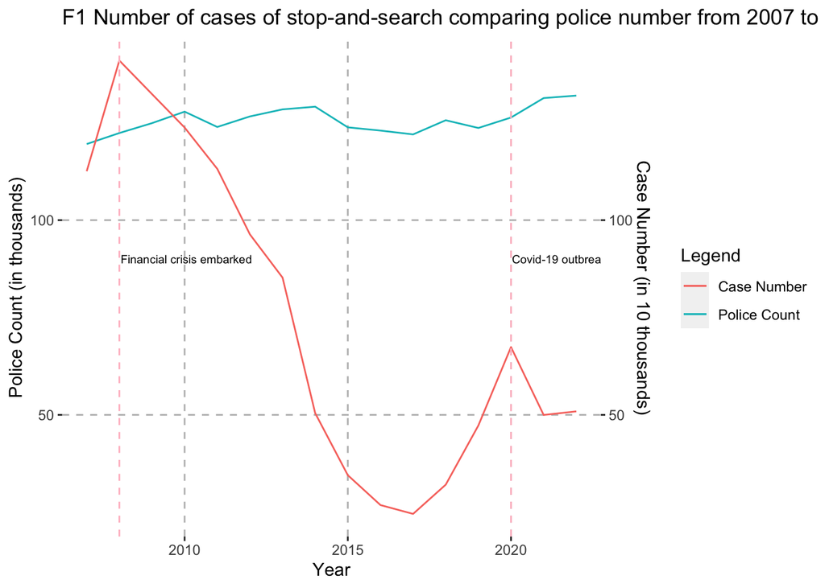

### 3.2 Temporal Analysis

#### - with a focus on ethnicity over time

In this section, the project endeavors to achieve a meaningful transformation of the stop-and-search cases by dividing them with the population based on ethnicity.

With a specific emphasis on ethnicity, the following visualizations illustrate the rate of individuals being subjected to stop-and-search practices in England and Wales. Despite variations in time frames, the two graphs reveal a noteworthy trend: individuals belonging to the black or black British ethnicity consistently exhibit a highest rate of being stopped, while the people in white ethnicity have the lowest.

The graph below shows stop-and-search practice with ethnicity from 2007 to 2023, with peak ratio of being stopped across whole population in the years 2008 and 2020.

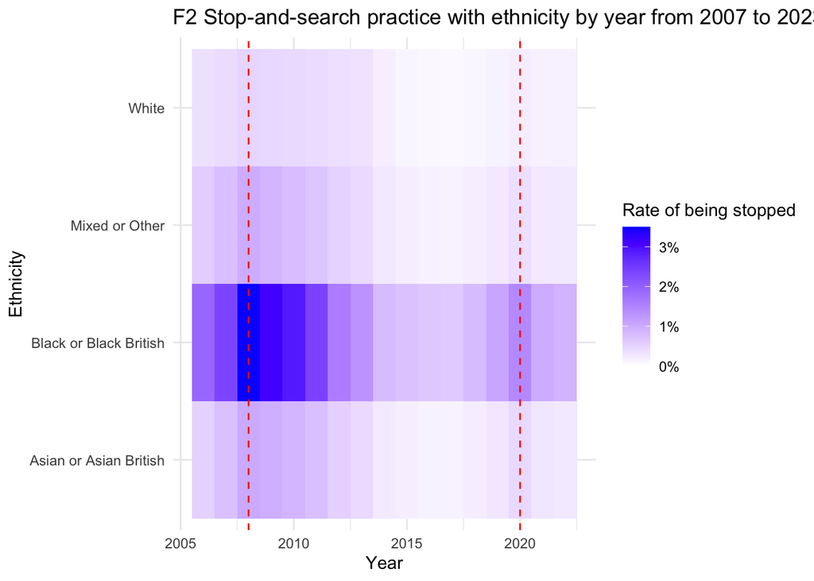

Figure 3 displays the correlation between being stopped and ethnicity quarterly from 2020 to 2022. It’s worth noting that the rate is the highest in the quarter during when Covid-19 pandemic outbreak.

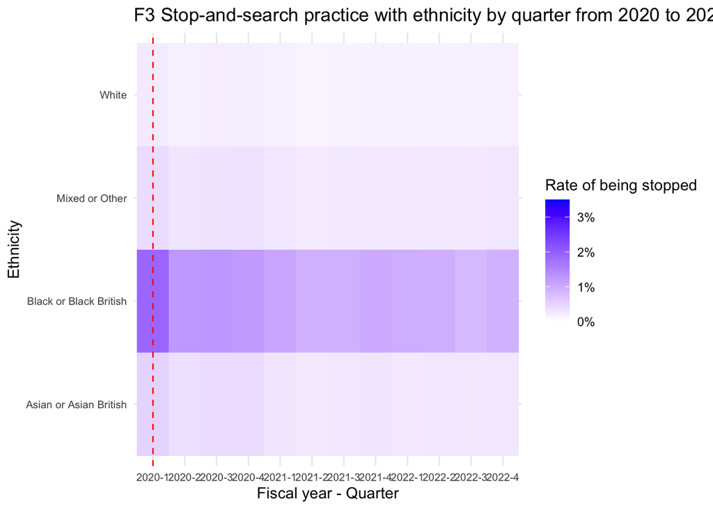

Based on the graphs above, we can confidently conclude that individuals of white ethnicity in England and Wales are less likely to be subjected to stop-and-search procedures compared with other ethnicities, as discerned from the case-population probability analysis.

### 3.3 Regional Analysis

In this segment, the project scrutinises potential biases associated with ethnicity and geographical region.

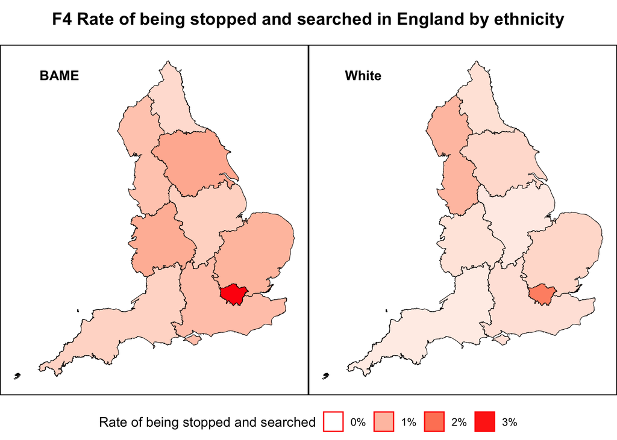

## 4. Conclusion

With a systematic analysis of case-population ratios, the project reveals potential biases in the UK police’s stop-and-search practices based on ethnicity. Examining various facets, particularly ethnicity and region, the research highlights a higher likelihood of individuals from BAME backgrounds being subjected to searches than that of white ethnicity. However, due to the lack of data, the project doesn’t include a statistical analysis to examine the causal relationship between ethnicity and biases.

## Appendix: All code in this project

```r
knitr::opts_chunk$set(echo = FALSE)
library(rvest)
library(tidyverse)
library(dplyr)
library(ggplot2)
library(scales)
####################################################################################
# Read the files needed into the environment
df_0720 <- read.csv("data/stop-search-open-data-tables-mar07-mar20.csv")
df_2123 <- read.csv("data/stop-search-open-data-mar21-mar23.csv")
police <- read.csv("data/PoliceNumber.csv")
census <- read.csv("data/census.csv")
census2011<-read.csv("data/census_2011.csv")

#--------------------------#--------------------------#--------------------------

# Modify the data set to make it clean and tidy (2007-2020 stop-and-search data)
df_0720_v1 <- df_0720%>%
  # Select only the interested variable
  select(Financial.Year,Geocode,Region,Reason.for.search...arrest, Ethnicity..self.defined.,Searches,Resultant.arrests)
# Rename the columns to make it tidy
colnames(df_0720_v1)<-c("Year","Geocode","Region","Reason","Ethnicity","Number","Result")
df_0720_v1$Number <- as.numeric(df_0720_v1$Number)
# Get the first four characters of the string as year variable, e.g. "2020/21 -> 2020"
df_0720_v1$Year <- as.numeric(substr(df_0720_v1$Year, 1, 4))

#--------------------------#--------------------------#--------------------------

df_0720_base <- df_0720_v1 %>%
# Delete any unspecific observations with no ethnicity type
  filter(Ethnicity != "Not Stated" & Ethnicity!="Vehicle only")%>%
  select(Year,Ethnicity,Number,Result,Region)%>%
  group_by(Year,Ethnicity,Region)%>%
  # Get the total number of cases based on year, ethnicity and region
  summarise(Case = sum(Number))
df_0720_base <- df_0720_base%>%
  # re-organise the ethnicity into four categories
  mutate(EthGroup = case_when(
    Ethnicity == "Black or Black British African" |
      Ethnicity == "Black or Black British Caribbean" |
      Ethnicity == "Other Black or Black British" ~ "Black or Black British",
    Ethnicity == "Bangladeshi or British Bangladeshi" |
      Ethnicity == "Pakistani or British Pakistani" |
      Ethnicity == "Chinese" |
      Ethnicity == "Indian or British Indian" |
      Ethnicity == "Other Asian or Asian British" ~ "Asian or Asian British",
    Ethnicity == "Mixed White and Asian" |
      Ethnicity == "Mixed White and Black African" |
      Ethnicity == "Mixed White and Black Caribbean" |
      Ethnicity == "Other" |
      Ethnicity == "Other Mixed" ~ "Mixed or Other",
    TRUE ~ "White"
  ))%>%
  # Select only the interested variable
  select(Year,EthGroup,Region,Case)
df_0720_base <- df_0720_base[,2:5]
# Rename the columns to make it tidy
colnames(df_0720_base)<-c("Year","Ethnicity","Region","Case")

#--------------------------#--------------------------#--------------------------

# Modify the data set to make it clean and tidy (2020-2023 quarterly data)
df_2123_v1 <- df_2123%>%
  # Select only the interested variable
  select(financial_year,geocode,region,reason_for_search,combined_ethnicity,number_of_searches,outcome,sex,age_group,financial_year_quarter)
# Rename the columns to make it tidy
colnames(df_2123_v1)<-c("Year","Geocode","Region","Reason","Ethnicity","Number","Result","Sex","Age","Quarter")
df_2123_v1$Number <- as.numeric(df_2123_v1$Number)
# Get the first four characters of the string as year variable, e.g. "2020/21 -> 2020"
df_2123_v1$Year <- as.numeric(substr(df_2123_v1$Year, 1, 4))
# Get the year-quarter data, e.g. "2020/1 -> 2020-1"
df_2123_v1$Date <- paste(df_2123_v1$Year, df_2123_v1$Quarter, sep = "-")
# Delete any unspecific observations with no ethnicity type
df_2123_v1<-filter(df_2123_v1,Ethnicity != "Unknown" & Ethnicity!="N/A - vehicle search" & Region != 0)
df_2123_base <- df_2123_v1 %>%
  select(Year,Ethnicity,Number,Result,Region)%>%
  group_by(Year,Ethnicity,Region)%>%
  # Get the total number of cases based on year, ethnicity and region
  summarise(Case = sum(Number))

#--------------------------#--------------------------#--------------------------

# Modify the police number data using the fulltime employment number
Police <- police%>%
  select(As.at.31.March...,Geo.code,Region,Ethnic.group,Total..FTE.)
# Rename the columns to make it tidy
colnames(Police)<-c("Year","Geocode","Region","Ethnicity","FTE")
Police$FTE <- as.numeric(Police$FTE)

#--------------------------#--------------------------#--------------------------

# Modify the census to get the population data from England and Wales
census2021 <- census%>%
  # Filter only the needed data for England and Wales
  filter(Geography.Name == "England and Wales")%>%
  # Make it tidy by pivot longer because the column names are the interested variable as ethnicity
  pivot_longer(cols = 4:22,names_to = "Ethnicity",values_to = "Number")
census2021$Number <- as.integer(census2021$Number)
census2021 <- census2021%>%
  group_by(Ethnicity)%>%
  summarise(Case_Number = sum(Number,na.rm = TRUE))%>%
  # Categorise the ethnicity into four groups and rename them
  mutate(EthGroup = case_when(
    grepl("^Asian", Ethnicity) ~ "Asian or Asian British",
    grepl("^Black", Ethnicity) ~ "Black or Black British",
    grepl("^White", Ethnicity) ~ "White",
    TRUE ~ "Mixed or Other"
  ))%>%
  select(-Ethnicity)%>%
  # Rename the columns to make it tidy
  rename(Ethnicity = EthGroup)%>%
  group_by(Ethnicity)%>%
  summarise(Population = sum(Case_Number))%>%
  mutate(Year = 2021)
census2011<-mutate(census2011,Year = 2011)
# Categorise the ethnicity into four groups and rename them
census2011$Ethnicity <- c("Asian or Asian British","Black or Black British","Mixed or Other","White")
# Categorise the ethnicity into four groups and rename them
census2021$Ethnicity <- c("Asian or Asian British","Black or Black British","Mixed or Other","White")
# Merge the 2021 census with 2011 census by ethnicity
census <- merge(census2011,census2021, by = "Ethnicity")
census <- census%>%
  select(Ethnicity,Population.x,Population.y)%>%
  rename(year2011 = Population.x)%>%
  rename(year2021 = Population.y)%>%
  mutate(CAGR = (year2021/year2011)^(1/10))
df_census = census
```

```r
#--------------------------#--------------------------#--------------------------

# To ascertain the annual ethnic population, the initial step involves calculating the combined aggregated growth rate (GAGR) spanning the period from the 2011 census to 2021. This calculated growth rate is then applied, using the Compound Annual Growth Rate (CAGR) methodology, to estimate the ethnic populations for the intervening years (2006-2010, 2012-2019, and 2022).
df_census <- mutate(df_census,year2006 = CAGR^(length(df_census)-9) * year2011)
df_census <- mutate(df_census,year2007 = CAGR^(length(df_census)-9) * year2011)
df_census <- mutate(df_census,year2008 = CAGR^(length(df_census)-9) * year2011)
df_census <- mutate(df_census,year2009 = CAGR^(length(df_census)-9) * year2011)
df_census <- mutate(df_census,year2010 = CAGR^(length(df_census)-9) * year2011)
df_census <- mutate(df_census,year2012 = CAGR^(length(df_census)-8) * year2011)
df_census <- mutate(df_census,year2013 = CAGR^(length(df_census)-8) * year2011)
df_census <- mutate(df_census,year2014 = CAGR^(length(df_census)-8) * year2011)
df_census <- mutate(df_census,year2015 = CAGR^(length(df_census)-8) * year2011)
df_census <- mutate(df_census,year2016 = CAGR^(length(df_census)-8) * year2011)
df_census <- mutate(df_census,year2017 = CAGR^(length(df_census)-8) * year2011)
df_census <- mutate(df_census,year2018 = CAGR^(length(df_census)-8) * year2011)
df_census <- mutate(df_census,year2019 = CAGR^(length(df_census)-8) * year2011)
df_census <- mutate(df_census,year2020 = CAGR^(length(df_census)-8) * year2011)
df_census <-df_census %>%
  mutate(year2022 = CAGR^(length(df_census)-17) * year2021)%>%
  select(-CAGR)%>%
  t()%>%as.data.frame()
# Rename the columns to make it tidy
colnames(df_census)<-df_census[1,]
df_census <- df_census[2:18,]
df_census$Year <- rownames(df_census)
df_census$Year <- as.numeric(substr(df_census$Year, 5, 8))
df_census <- df_census %>%
  # Pivot longer to get the tidy version of population based on ethnicity and year
  pivot_longer(cols = colnames(df_census)[1:4], names_to = "Ethnicity",values_to = "Population")%>%
  arrange(Year)
df_census$Population <- as.numeric(df_census$Population)

####################################################################################

# Get the database for analysis 1 which combines police number and stop-and-search data from 2007 to 2023
# Rbind the data from 2007 to 2020 with data from 2020 to 2023
A1 <- rbind(df_0720_base,df_2123_base)
# Get the annual case number
A1 <- A1 %>%
  group_by(Year)%>%
  summarise(CaseNumber = sum(Case))
# Get the annual police number
police_a1 <- Police %>%
  group_by(Year)%>%
  summarise(police = sum(FTE,na.rm = TRUE))

# Merge police number and stop-and-search data
A1_data <- merge(A1,police_a1,by = "Year")

####################################################################################
# Plot for analysis 1 with two lines of police number and case number
A1graph <- ggplot(A1_data, aes(x = Year)) +
  geom_line(aes(y = police/1000, color = "Police Count")) +
  geom_line(aes(y = CaseNumber/10000, color = "Case Number")) +
  # Re-scale the axis to make it comparable
  scale_y_continuous(
    name = "Police Count (in thousands)",
    breaks = waiver()
  ) +
  scale_y_continuous(
    sec.axis = sec_axis(
      trans = ~ . ,
      name = "Case Number (in 10 thousands)",
      breaks = waiver()
    )
  ) +
  # Highlight the year 2020 and 2008
  geom_vline(xintercept = 2020, linetype = "dashed", color = "pink") +
    annotate("text", x = 2020, y = 90, label = "Covid-19 outbreak", hjust = -0.01, size = 2.5)+
  geom_vline(xintercept = 2008, linetype = "dashed", color = "pink") +
    annotate("text", x = 2008, y = 90, label = "Financial crisis embarked", hjust = -0.01, size = 2.5)+
  # Set the title, axis name and the legend
  labs(title = "F1 Number of cases of stop-and-search comparing police number from 2007 to 2022",
       x = "Year",
       y = "Police Count (in thousands)",
       color = "Legend") +
  theme(panel.grid.major = element_line(color = "grey", size = 0.5, linetype = "dashed"),
        panel.background = element_rect(fill = "transparent"))
A1graph

####################################################################################
# Get the database for analysis 2 which combines ethnic variable and stop-and-search cases from 2007 to 2023
# Rbind the data from 2007 to 2020 with data from 2020 to 2023
A2 <- rbind(df_0720_base,df_2123_base)
# Get the annual case number by year and ethnicity
A2 <- A2 %>%
  group_by(Year,Ethnicity)%>%
  summarise(Case_Number = sum(Case))
# Cbind the case number data with the population data
A2_data1 <- cbind(A2,df_census)
A2_data1 <- A2_data1 %>%
  # Select the important variables
  select(Year...1,Ethnicity...2,Case_Number,Population)%>%
  rename(Year = Year...1)%>%
  rename(Ethnicity = Ethnicity...2)%>%
  # Get the meaningful ratio of being stopped by dividing case_number by population in certain ethnicity
  mutate(rate = Case_Number / Population)

# Get the quarterly case number
A2_data2 <- df_2123_v1 %>%
  group_by(Date,Ethnicity)%>%
  summarise(Case_Number = sum(Number))
# Merge the quarterly data with population data in 2021 and set the population as a fixed number across 2020 - 2022
A2_data2 <- merge(A2_data2,census2021,by="Ethnicity")
# Get the meaningful ratio of being stopped by dividing case_number by population in certain ethnicity
A2_data2$rate = A2_data2$Case_Number/A2_data2$Population

####################################################################################
# Plot heatmap from year 2007 to 2023
ggplot(A2_data1, aes(Year, Ethnicity,
            # Because the yearly data aggregate four quarters, so the ratio must be much higher than the quarterly data. It's important to divide the yearly rate by four in order to re-scale it and make it comparable with the quarterly data.
                     fill = rate/4)) +
  geom_tile() +
  # Highlight the year 2020 and 2008
  geom_vline(xintercept = 2020, linetype = "dashed", color = "red") +
  geom_vline(xintercept = 2008, linetype = "dashed", color = "red") +
  # Set the title, axis name and the legend
  labs(fill = "Rate of being stopped",
       title = "F2 Stop-and-search practice with ethnicity by year from 2007 to 2023",
       x = "Year",
       y = "Ethnicity",
       size = 6)+
  scale_fill_gradient(
    low = "white", high = "blue",
    limits = c(0, 0.035),  # Set the desired scale limits
    labels = scales::percent_format(scale = 100)  # Format labels as percentage
  )+theme_minimal()
```

```r
####################################################################################
# Plot heatmap by quarter from 2021 to 2023
ggplot(A2_data2, aes(Date, Ethnicity, fill = rate)) +
  geom_tile() +
  scale_fill_gradient(
    low = "white", high = "blue",
    limits = c(0, 0.035),# Set limits of the scale to make it comparable
    labels = scales::percent_format(scale = 100)) +
  # Highlight the first fiscal quarter of 2020 (Apr 2020 - Jun 2020)
  geom_vline(xintercept = "2020-1", linetype = "dashed", color = "red") +
  # Set the title, axis name and the legend
  labs(fill = "Rate of being stopped",
       title = "F3 Stop-and-search practice with ethnicity by quarter from 2020 to 2022",
       x = "Fiscal year - Quarter",
       y = "Ethnicity",
       size = 6)+
  theme_minimal()+
  theme(axis.text = element_text(size = 7.5))

####################################################################################
library(sf)
library(rnaturalearthhires)
library(rnaturalearth)
library(ggplot2)
library(cowplot)

####################################################################################
# Load the map shapefile of England
england <- st_read("data/shapefile/english_region_region.shp")
england$Region <- gsub(" English Region", "", england$NAME)

####################################################################################
# Load the population data by region and ethnic
pop_by_region <- read.csv("data/ethnic_pop_region.csv")

# Modify it to a tidy form
pop_ethnic <- pop_by_region%>%
  pivot_longer(cols = colnames(pop_by_region)[4:22], names_to = "Ethnicity", values_to = "pop")%>%
  # Categorise the ethnicity into four groups
  mutate(EthGroup = case_when(
    grepl("^Asian", Ethnicity) ~ "Asian or Asian British",
    grepl("^Black", Ethnicity) ~ "Black or Black British",
    grepl("^White", Ethnicity) ~ "White",
    TRUE ~ "Mixed or Other"
  ))%>%
  group_by(Geography.Name, EthGroup)%>%
  # Get the population by region and ethnicity
  mutate(Pop = sum(pop, na.rm= TRUE))%>%
  select(-Sex,-pop)

# Select the right region range for the mapping
A3_pop <- pop_ethnic[11667:12008,c(1,2,4,5)]%>%
  # Remove the NA value
  filter(!is.na(Pop))%>%
  rename(Ethnicity = EthGroup)%>%
  rename(Region = Geography.Name)%>%
  distinct(.keep_all = TRUE)%>%
  # Sort the data according to region and ethnicity
  arrange(Region,Ethnicity)

# Select only the BAME population
A3_BAMEpop <- A3_pop%>%
  filter(Ethnicity != "White")%>%
  group_by(Region)%>%
  summarise(Population = sum(Pop))

# Select only the White population
A3_WHITEpop <- A3_pop%>%
  filter(Ethnicity == "White")%>%
  group_by(Region)%>%
  summarise(Population = sum(Pop))

####################################################################################
# Prepare the data for mapping with geometry information for the BAME ethnicity
A3_data1 <- df_2123_base%>%
  filter(Ethnicity != "White")%>%
  filter(Year == 2021)%>%
  filter(Region != "Wales")%>%
  distinct(.keep_all = TRUE)%>%
  arrange(Region,Ethnicity)
A3_data1 <- A3_data1%>%
  group_by(Region)%>%
  summarise(BAME = sum(Case))%>%
  distinct(.keep_all = TRUE)
# Merge the ratio data with the geometry information
A3_data1 <- merge(A3_data1, A3_BAMEpop, by = "Region", all.x = TRUE)

# Get the interested rate of being stopped
A3_data1$rate <- A3_data1$BAME/A3_data1$Population
A3_data1 <- merge(A3_data1,england,by = "Region", all.x = TRUE)

# Prepare the data for mapping with geometry information for the white ethnicity
A3_data2 <- df_2123_base%>%
  filter(Ethnicity == "White")%>%
  filter(Year == 2021)%>%
  filter(Region != "Wales")%>%
  distinct(.keep_all = TRUE)%>%
  arrange(Region,Ethnicity)
A3_data2 <- A3_data2%>%
  group_by(Region)%>%
  summarise(BAME = sum(Case))%>%
  distinct(.keep_all = TRUE)
# Merge the ratio data with the geometry information
A3_data2 <- merge(A3_data2, A3_WHITEpop, by = "Region", all.x = TRUE)

# Get the interested rate of being stopped
A3_data2$rate <- A3_data2$BAME/A3_data2$Population
A3_data2 <- merge(A3_data2,england,by = "Region", all.x = TRUE)

####################################################################################
# Plot the map for the BAME ethnicities
map1 <- ggplot()+
  # Fill the ratio into the map and the color to show the intensity
  geom_sf(data = A3_data1, aes(fill = rate, geometry = geometry), color = "black")+
  scale_fill_gradient(low = "white", high = "red",
                      limits = c(0, 0.032)) + #Set limits for the scale
  theme_void() +
  theme(legend.position = "none", # Remove legend
        panel.grid = element_blank(),  # Remove grid
        panel.border = element_rect(color = "black", fill = "transparent", linewidth = 0.6),
        axis.text = element_blank())

# Plot the map for the white ethnicity
map2 <- ggplot()+
  # Fill the ratio into the map and the color to show the intensity
  geom_sf(data = A3_data2, aes(fill = rate, geometry = geometry), color = "black")+
  scale_fill_gradient(low = "white", high = "red",
                      limits = c(0, 0.032)) +
  theme_void() +
  theme(legend.position = "none", # Remove legend
        panel.grid = element_blank(),  # Remove grid
        panel.border = element_rect(color = "black", fill = "transparent", linewidth = 0.6),
        axis.text = element_blank())

####################################################################################
# Set the legend and title blocks for plotting
legend <- cowplot::get_legend(ggplot() +
                                geom_sf(data = A3_data1, aes(fill = rate, geometry = geometry), color = "red") +
                                scale_fill_gradient(low = "white", high = "red",
                                                    limits = c(0, 0.032),
                                                    labels = scales::label_percent())+
                                theme_void() +
                                theme(legend.position = "bottom") +
                                guides(fill = guide_legend(title = "Rate of being stopped and searched")))
title <- ggdraw() +
  draw_label("F4 Rate of being stopped and searched in England by ethnicity", fontface = "bold", size = 14,y = 0.5)
```

```r
####################################################################################
# Plot the map with two columns
# Use function plot_grid to arrange facets
combined_map <- plot_grid(title,# First row as title
                          # Second row with the two maps
                          plot_grid(map1, map2, ncol = 2,
                          labels = c("BAME", "White"),
                          align = "t",
                          label_size = 11,
                          vjust = 4.5,
                          hjust = -1),
                          # Third row with legend
                          legend,
                          ncol = 1,
                          rel_heights = c(0.1, 1, 0.1))
combined_map
```